# Regresión lineal y series de tiempo con Python y R

Autor: Luis Apáez Álvarez

Fecha: 30 de diciembre del 2022

```r
library(knitr)
include_graphics("images.jpg")
```

`R` es un conjunto de programas para cálculo numérico, creación de gráficos, manipulación de datos, análisis estadísticos, aprendizaje automático, entre muchas otras más. Iniciaremos el curso indagando en los conceptos más fundamentales (como lenguaje de programación) del mismo para enfocarnos en temas de probabilidad y análisis estadístico.

## Conceptos básicos

### Artimética

Comenzaremos viendo que `R` puede realizar de manera directa operaciones como si fuera una calculadora:

```r
# Esto es un comentario, solo sirve para hacer anotaciones en nuestras celdas de codigo.
# ------
# SUMA
41 + 8
```

```
## [1] 49
```

```r
# MULTIPLICACION
4 * 7
```

```
## [1] 28
```

```r
# DIVISION
14 / 7
```

```
## [1] 2
```

```r
# POTENCIA
2 ** 3
```

```
## [1] 8
```

Resaltamos que `R` ejecuta el código de arriba hacía abajo. Además, una alternativa para `**` a la hora de la exponenciación es el símbolo `^`

```r
# POTENCIA (ALTERNATIVA)
2 ^ 3
```

```
## [1] 8
```

Para el operador de residuo utilizamos `%%`. Por ejemplo, el residuo de efectuar la división $\frac{5}{2}$ es uno, por lo cual

```r
5 %% 2
```

```
## [1] 1
```

### Variables

Podemos utilizar variables para almacenar información. Por ejemplo, en la celda de código anterior obtivimos el residuo de dividir 5 entre 2, pero puede ser que querramos almacenar dicho valor en una variable para utilizarla después. Para asignar un valor a una variable utilizamos el operador `<-`, o equivalentemente el operador `=`. Éstos significan exactamente lo mismo: asignación.

```r
# Asignamos a la variable x el valor resultante de 5 %% 2
x <- 5 %% 2
```

Ahora podemos utilizar la variable `x` en celdas de código posteriores:

```r
# Al residuo de dividir 5 entre 2, le sumamos un 10
x + 10
```

```
## [1] 11
```

Apesar de que a `x` le sumamos un 10, el valor de `x` sigue siendo el mismo

```r
x
```

```
## [1] 1
```

Si queremos almacenar un resultado, deberemos asignarlo a una variable

```r
# Definimos una nueva variable con la notacion alternativa de =
y = x + 10
# Veamos el valor de la variable y
y
```

```
## [1] 11
```

```r
# Cambiamos el valor almacenada de la x
x <- 11
# Veamos el valor actual de la x
x
```

```
## [1] 11
```

Podemos operar aritméticamente con las variables

```r
# Potencia
y ^ x
```

```
## [1] 285311670611
```

### Vectores

Los vectores representan conjuntos de datos ordenados, por ejemplo $(1,5)$ es un vector, o también $(0,1,5,4.2)$ es un vector, donde vemos que están ordenados pues, para $(1,5)$, tenemos que el número 1 está en la primera posición (o entrada) del vector y el 5 en la segunda posición. Definimos vectores en `R` utilizando la función `c()`. Por ejemplo

```r
# Definimos dos vectores
vector1 <- c(1, 5)
vector2 <- c(0,1,5,4.2)
vector3 <- c(2, -8)

# Veamos los vectores
vector1
```

```
## [1] 1 5
```

```r
vector2
```

```
## [1] 0.0 1.0 5.0 4.2
```

```r
vector3
```

```
## [1]  2 -8
```

Podemos operar aritméticamente los vectores, donde las operaciones se harán entrada a entrada. Por ejemplo:

```r
# Sumamos dos vectores
vector1 + vector3
```

```
## [1]  3 -3
```

donde la suma se realizó entrada a entrada.

```r
# Multiplicamos dos vectores
vector1 * vector3
```

```
## [1]   2 -40
```

Etcétera. Podemos obtener el número de elementos que tiene un vector utilizando la función `length()`

```r
# Numero de elementos de cada vector
length(vector1)
```

```
## [1] 2
```

```r
length(vector2)
```

```
## [1] 4
```

```r
length(vector3)
```

```
## [1] 2
```

Ya vimos cómo sumar dos vectores, pero también podemos sumar todas las entradas de un vector. Por ejemplo:

```r
# Definimos un vector nuevo
ganancias <- c(100, 1500, 20)
# Suma de las ganancias
sum(ganancias)
```

```
## [1] 1620
```

O también podemos obtener el promedio de las entradas de un vector

```r
# Promedio de las ganancias
mean(ganancias)
```

```
## [1] 540
```

Podemos ordenar el vector de menor a mayor con la función `sort()`

```r
sort(ganancias)
```

```
## [1]   20  100 1500
```

o de mayor a menor

```r
sort(ganancias, decreasing = TRUE)
```

```
## [1] 1500  100   20
```

Veamos que los vectores en `R` son muy vérsatiles, y de hecho serán de gran utilidad al utilizarlos como estructuras de datos. Podemos agregar elementos nuevos a un vector, utilizando la función `append()`:

```r
# Al vector de ganancias le agregamos una nueva entrada
#                nueva entrada
#                al vector
append(ganancias, 70)
```

```
## [1]  100 1500   20   70
```

### Generación de secuencias

Supongamos que definimos el vector

```r
vect1 <- c(1,2,3,4,5,6,7,8,9)
vect1
```

```
## [1] 1 2 3 4 5 6 7 8 9
```

puede ser una labor tediosa definir un vector que contenga todos los números enteros del 1 al 100, así como lo definimos manualmente para el caso del 1 al 9. Para ello podemos generar secuencias de números:

```r
# Secuencia de enteros del 1 al 9
1:9
```

```
## [1] 1 2 3 4 5 6 7 8 9
```

O también

```r
# Secuencia de enteros del 1 al 100 almacenada en una variable
seq1 = 1:100
seq1
```

```
##   [1]   1   2   3   4   5   6   7   8   9  10  11  12  13  14  15  16  17  18
##  [19]  19  20  21  22  23  24  25  26  27  28  29  30  31  32  33  34  35  36
##  [37]  37  38  39  40  41  42  43  44  45  46  47  48  49  50  51  52  53  54
##  [55]  55  56  57  58  59  60  61  62  63  64  65  66  67  68  69  70  71  72
##  [73]  73  74  75  76  77  78  79  80  81  82  83  84  85  86  87  88  89  90
##  [91]  91  92  93  94  95  96  97  98  99 100
```

Donde en las secuencias anteriores el incremento es de uno en uno. Como alternativa para crear secuencias, podemos utilizar `seq()`. Así, `1:100` es totalmente equivalente a `seq(1, 100)`. Con la función `seq()` podemos modificar el incremento

Podemos modificar el incremento:

```r
# Secuencia del 1 al 9 modificando el incremento
seq2 <- seq(1, 9, by=0.5)
seq2
```

```
##  [1] 1.0 1.5 2.0 2.5 3.0 3.5 4.0 4.5 5.0 5.5 6.0 6.5 7.0 7.5 8.0 8.5 9.0
```

### Tipos de datos

Los números enteros y decimales son tipos de datos numéricos (`numeric`). Existen otros tipos de datos importantes con los cuales trabajaremos:

- Cadenas de texto (`character`): Nos permiten colocar lenguaje natural (lenguaje que utilizamos entre nosotros para comunicarnos) dentro de las celdas de código, para lo cual encerramos el texto entre comillas dobles o simples. Por ejemplo

```r
# Definimos una variable del tipo character
saludo <- "Hola Mundo"
saludo
```

```
## [1] "Hola Mundo"
```

- Booleanos (`logical`): Son datos lógicos, los cuales solo pueden ser o `TRUE` (verdadero) o `FALSE` (falsos).

```r
# Definiendo una variable booleana
esta_lloviendo <- FALSE
esta_lloviendo
```

```
## [1] FALSE
```

Notemos que escribimos `esta_lloviendo` uniendo las palabras mediante el guión bajo pues, no podemos definir variables dejando espacios en blanco:

```r
# Obtendremos un error:

# Definiendo una variable booleana
esta lloviendo <- FALSE
esta lloviendo
```

```
## Error: <text>:4:6: unexpected symbol
## 3: # Definiendo una variable booleana
## 4: esta lloviendo
##         ^
```

Las variables booleanas son muy importantes, además de que podemos combinarlas con operadores booleanos:

- Operador or (`|`): Considera dos variables booleanas y regresa una variable booleana, donde:
  - `TRUE | TRUE` regresa `TRUE`
  - `TRUE | FALSE` regresa `TRUE`
  - `FALSE | TRUE` regresa `TRUE`
  - `FALSE | FALSE` regresa `FALSE`

```r
# Veamos dos ejemplos aplicando el operador or (|)
TRUE | FALSE
```

```
## [1] TRUE
```

```r
FALSE | FALSE
```

```
## [1] FALSE
```

- Operador and (`&`): Considera dos variables booleanas y regresa una variable booleana, donde:
  - `TRUE & TRUE` regresa `TRUE`
  - `TRUE & FALSE` regresa `FALSE`
  - `FALSE & TRUE` regresa `FALSE`
  - `FALSE & FALSE` regresa `FALSE`

```r
# Veamos dos ejemplos aplicando el operador and (&)
TRUE & TRUE
```

```
## [1] TRUE
```

```r
FALSE & FALSE
```

```
## [1] FALSE
```

- Operador de negación (`!`): Considera una variable booleana y regresa una variable booleana, donde:
  - `!TRUE` regresa `FALSe`
  - `!FALSE` regresa `TRUE`

```r
# Veamos un ejemplo del operador de negacion
!TRUE
```

```
## [1] FALSE
```

Cabe mencionar que hasta ahora para ver algún tipo de dato o una variable simplemente escribimos dicho dato o dicha variable en una línea nueva para poder verla en consola. Esto es

```r
# Definimos una variable:
# (Podemos combinar operadores booleanos)
#               (TRUE)
bool1 <- TRUE & !FALSE
# Para ver el valor de dicha variable escribimos en una linea nueva sun nombre que le asignamos
bool1
```

```
## [1] TRUE
```

De manera alternativa podemos utilizar la función `print()` para ver los resultados en salida:

```r
print(bool1)
```

```
## [1] TRUE
```

### Condicionales

Los condicionales corresponden a una estructura en la cual ejecutaremos una acción si cierta condición es verdadera, y ejecutaremos otra acción para el caso en que dicha condición sea falsa. Por ejemplo consideremos la siguiente idea

- Si el semáforo está en verde, entonces no cruzamos la calle. Tenemos en dicho ejemplo que la condición es “el semáforo está en verde”; si dicha condición es verdadera, entonces no cruzamos la calle; si dicha condición es falsa, cruzaremos la calle. De tal modo realizaremos alguna acción en caso de que la condición impuesta sea o no verdadera.

Podemos implementar condicionales en `R` siguiendo la siguiente estructura:

```
if (condicion) {
  acciones a realizar en caso de que la condicion
  sea verdadera
} else {
  acciones a realizar en caso de que la condicion
  sea verdadera
}
```

Por ejemplo

```r
# Condicion
semaforo_en_verde = TRUE

# Implementamos el condicional if
if (semaforo_en_verde) {
  # Accion a realizar en caso de que la condicion sea verdadera:
  # Imprimieremos un mensaje
  print("No cruzar")
} else {
  # Accion a realizar en caso de que la condicion sea falsa:
  # Imprimieremos un mensaje
  print("Puedes cruzar")
}
```

```
## [1] "No cruzar"
```

Dado que la condición impuesta es verdadera, entonces se ha impreso el mensaje `"No cruzar"`.

Veamos un ejemplo práctico. Escribiremos un código para determinar si un número es par o impar. Para ello utilizaremos el siguiente criterio: un número entero $n$ es par si el residuo de la división $\frac{n}{2}$ es cero. En caso contrario el número $n$ será impar. Así:

```r
# Identificador de numeros pares e impares.
# Definimos el numero n:
n = 7
# Implementamos un condicional
if (n %% 2 == 0) {
  print("El número considerado es par")
} else {
  print("El número considerado es impar")
}
```

```
## [1] "El número considerado es impar"
```

donde el símbolo `==` significa igualdad, pues recordemos que el símbolo `=` significa asignación. Luego, la condición `n %% 2 == 0` puede leerse como: el residuo de dividir n entre 2 es igual a 0. Lo anterior puede ser verdadero o falso, según sea el valor de $n$, lo cual nos arrojará un booleano (`FALSE` o `TRUE`).

### Bucles

#### Bucle `for`

Como su nombre lo indica, el bucle `for` representa un proceso repetitivo, donde ciertas instrucciones se estarán **repitiendo un número determinado de veces**. Por ejemplo, consideremos un vector e imprimamos cada uno de sus elementos

```r
# Vector con entradas de varios tipos de datos
vect2 <- c(10, 'nombre', FALSE)
# Podemos imprimir el PRIMER ELEMENTO del vector anterior colocando entre corchetes el numero 1
print(vect2[1])
```

```
## [1] "10"
```

```r
# Imprimimos el segundo elemento
print(vect2[2])
```

```
## [1] "nombre"
```

```r
# Imprimimos el tercer elemento
print(vect2[3])
```

```
## [1] "FALSE"
```

Supongamos que tenemos un vector con 100 entradas y queremos imprimir cada una de ellas. Si realizamos el mismo proceso anterior pero ahora para el vector de 100 entradas, tardaremos un tiempo considerable. Como alternativa podemos utilizar un bucle `for` cuya estructura básica es:

```
for (recorrido) {
  acción a repetir
}
```

Por ejemplo

```r
# Creamos un vector
vect_recorrido <- 1:3
vect_recorrido
```

```
## [1] 1 2 3
```

el cual tiene los elementos que ocupamos para acceder a todos los elementos del vector `vect2`. Luego implementamos el `for`

```r
for (i in vect_recorrido){
  # Accion a ejecutar repetidamente
  print(vect2[i])
}
```

```
## [1] "10"
## [1] "nombre"
## [1] "FALSE"
```

donde la `i` es una variable propia del bucle `for` (y en realidad puede llamarse como sea). La variable del `for` recorrerá cada elemento del vector `vect_recorrido` de la siguiente manera:

- Inicialmente en el bucle la `i` vale 1 (que es el primer valor del vector `vect_recorrido`) y así se ejecuta la acción `print(vect2[i])`, pero `i` vale 1, por lo cual se ejecuta `print(vect2[1])`, lo que nos arroja `"10"`.
- Luego, la `i` vale 2 (que es el segundo elemento del vector `vect_recorrido`) y por ello se ejecuta `print(vect2[2])` que nos arroja `"nombre"`.
- Finalmente se ejecuta ```print(vect2[3])` que nos arroja `"FALSE"`.

El bucle finaliza cuando la `i` recorre todos los elementos de `vect_recorrido`. Veamos una alternativa del código anterior

```r
# directamente colocamos la secuencia del 1 al 3
for (i in 1:3){
  # Accion a ejecutar repetidamente
  print(vect2[i])
}
```

```
## [1] "10"
## [1] "nombre"
## [1] "FALSE"
```

O también, directamente podemos recorrer los elementos del vector `Vect2`:

```r
# Recorremos directamente los elementos de vect2
for (i in vect2){
  # Accion a ejecutar repetidamente
  print(i)
}
```

```
## [1] "10"
## [1] "nombre"
## [1] "FALSE"
```

donde en este caso:

- Al inicio la `i` tomará el valor de `"10"`.
- En la siguiente iteración la `i` tomará el valor de `"nombre"`.
- Finalmente la `i` tomará el valor de `"FALSE"` y el bucle termina.

Veamos un ejemplo práctico. Lo que haremos será definir un vector sin elementos, y en éste le iremos agregando únicamente los números pares en el rango del 1 al 50:

```r
# Definimos un vector con la secuencia de numeros del 1 al 50
secuencia <- 1:50

# definimos un vector vacio para ir almacenando los numeros pares
pares <- c()

# Implementamos el for
for (i in secuencia){
  # Utilizaremos un condicional para detectar los numeros pares
  if (i %% 2 == 0){
    # Si i es par, lo agregamos a la lista pares
    pares = append(pares, i)
  }
}
# Veamos
pares
```

```
##  [1]  2  4  6  8 10 12 14 16 18 20 22 24 26 28 30 32 34 36 38 40 42 44 46 48 50
```

donde:

- Con el bucle `for` recorrimos todos los elementos del 1 al 50.
- Con el condicional `if` filtramos solo los numeros pares. Dichos paremos los agregamos a la lista pares `append(pares, i)`, pero para guardar la lista paremos con los elementos nuevos debemos estar actualizando la variable `pares`, por lo cual escribimos `pares = append(pares, i)`.
- El bucle funciona de la siguiente manera:
  - En la primera iteración la `i` vale 1, como el 1 no es par, entonces pasamos a la siguiente iteración.
  - En la siguiente iteración la `i` vale 2, como el dos es par, entonces `append(pares, i)` resulta en el vector `c(2)`. Para guardar ese vector resultanto lo almacenamos en la variable `pares`.
  - En la cuarta iteración la `i` vale 4, de modo que `append(pares, i)` resulta en el vector `c(2, 4)` y guardamos ese vector en la variable `pares`.
  - Y así sucesivamente.

#### Bucle `while`

El bucle `while` es muy similar al `for`. El bucle `for` repite instrucciones un número determinado de veces, pero el bucle `while` repetirá la instrucción mientras una condición sea verdadera. Cuando dicha condición impuesta sea falsa, el bucle `while` finalizará. La estructura básica es

```
while (condicion) {
  acción a repetir
}
```

Debemos ser cuidadosos con el bucle `while` pues si la condición que imponemos nunca será falsa, entonces, en teoría, el bucle `while` tampoco se detendrá. Así, dentro del código del `while` debemos escribir el código necesario para evitar que el bucle `while` sea “infinito”. Veamos algunos ejemplos

```r
# Definimos la condicion del while
continuar = TRUE

# Definiremos un contador auxiliar
contador <- 0
while (continuar){
  print("Hola")
  # Aumentaremos en uno el contador
  contador = contador + 1
  # Implementamos un condicional para hacer que el
  # bucle no sea infinito
  if (contador == 3){
    continuar = FALSE
  }
}
```

```
## [1] "Hola"
## [1] "Hola"
## [1] "Hola"
```

donde:

- En la primer iteración la variable `continuar` es verdadera por lo que se ejecuta `print("hola")`. Aumentamos en uno el contador, por lo cual `contador` ahora vale 1. Luego, en el `if` vemos su `contador==3`, lo cual es falso pues ahora `contador` vale 1, de modo que `continuar` sigue siendo verdadera.
- En la segunda iteración `contador` vale 2 y de nuevo se ejecuta `print("hola")`.
- En la tercera iteración `contador` vale 3 y de nuevo se ejecuta `print("hola")`. Pero ahora `continuar==3` es verdadera, por lo cual se ejecuta la acción del condicional, así `continuar` ahora será falsa y por ende el bucle `while` finaliza. Es usual utilizar variables como contadores para hacer que el bucle `while` no sea infinito. Abordemos otro ejemplo

```r
# Definimos una variable inicial en 0
n <- 0
# Ejecutamos un bucle while mientras n sea menor a 10
while (n < 10){
  # Imprimos el valor de n
  print(n)
  # aumentamos en 1 el valor de la n para que eventualmente el bucle se detenga
  n = n + 1
}
```

```
## [1] 0
## [1] 1
## [1] 2
## [1] 3
## [1] 4
## [1] 5
## [1] 6
## [1] 7
## [1] 8
## [1] 9
```

En resumen vemos que el funcionamiento del `while` y del `for` son muy similares.

### Lectura de datos

Dentro de `R` existen librería que traen funcionalidades adicionales. Por ejemplo, en la librería `datasets` vienen integrados varios conjuntos de datos, por ejemplo:

```r
# Cargamos la libreria datasets para poderla utilizar
library(datasets)

# De la libreria datasets accedemos al conjunto de datos iris
data <- datasets::iris

# Veamos
head(data)
```

|  | Sepal.Length | Sepal.Width | Petal.Length | Petal.Width | Species |
| --- | --- | --- | --- | --- | --- |
| 1 | 5.1 | 3.5 | 1.4 | 0.2 | setosa |
| 2 | 4.9 | 3.0 | 1.4 | 0.2 | setosa |
| 3 | 4.7 | 3.2 | 1.3 | 0.2 | setosa |
| 4 | 4.6 | 3.1 | 1.5 | 0.2 | setosa |
| 5 | 5.0 | 3.6 | 1.4 | 0.2 | setosa |
| 6 | 5.4 | 3.9 | 1.7 | 0.4 | setosa |

con la función `head()` solo vemos la información de las primeras 6 filas. O podemos especificar el número de fulas que queremos ver si escribimos `head(data, 10)` para ver las 10 primeras filas.

Podemos acceder a la información de una columna en específico

```r
# Vemos los primeros 6 valores de la columna Petal.Length escribiendo para ello data$Petal.Length

head(data$Petal.Length)
```

```
## [1] 1.4 1.4 1.3 1.5 1.4 1.7
```

esto es, dado un conjunto de datos, accedemos a los elementos de una columna utilizando el símbolo `$`. Adicionalmente, podemos acceder a un número determinado de filas y columnas:

```r
# Entre corchetes escribimos:
# [numero de fila, numero de columna]
data[1, 3]
```

```
## [1] 1.4
```

O también podemos obtener rangos de filas y/o de columnas

```r
# Datos de la fila 1 a la 3 considerando solo las columnas de la 2 a la 5
data[1:3, 2:5]
```

|  | Sepal.Width | Petal.Length | Petal.Width | Species |
| --- | --- | --- | --- | --- |
| 1 | 3.5 | 1.4 | 0.2 | setosa |
| 2 | 3.0 | 1.4 | 0.2 | setosa |
| 3 | 3.2 | 1.3 | 0.2 | setosa |

Por otro lado, con la función `plot()` podemos crear gráficos, por ejemplo

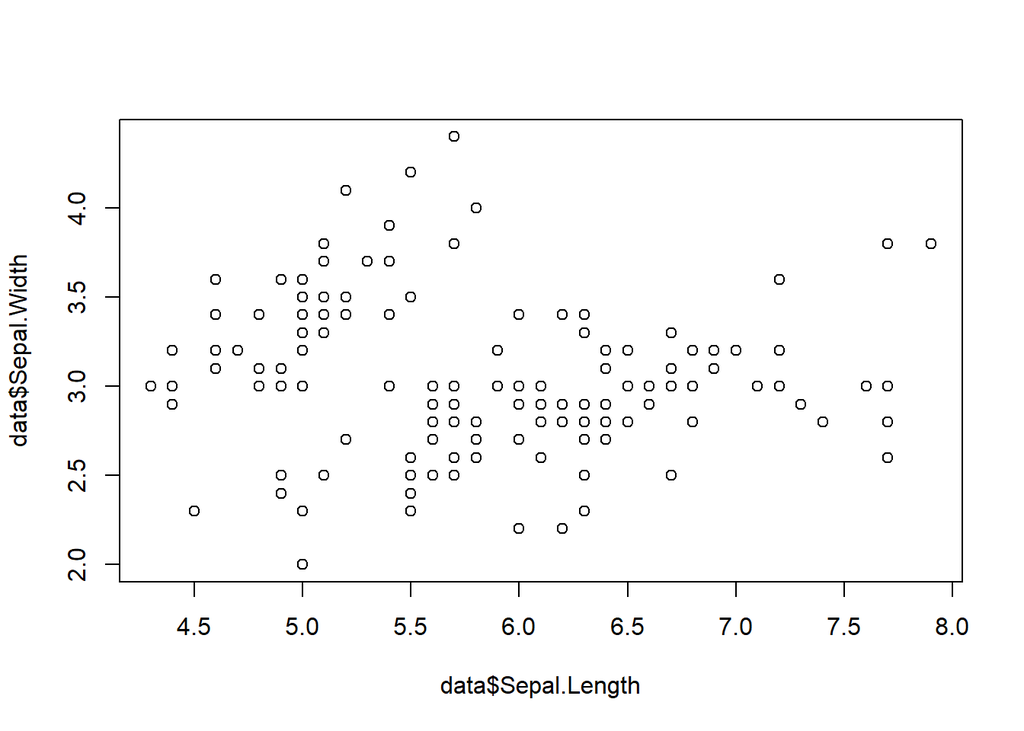

```r
#    eje x                eje y
plot(x=data$Sepal.Length, y=data$Sepal.Width)
```

En clases posteriores veremos más a detalle el manejo de datos, carga de datos y su manipulación, así como otros tipos de gráficos o personalización de los mismos.

## Introducción a Python

```r
library(knitr)
include_graphics("pylogo.png")
```

Lo que haremos a continuación será ver los mismos temas anteriores pero ahora utilizando `Python`. De tal manera comenzamos por:

#### Aritmética

```python
# Esto es un comentario
# SUMA
1 + 3
# MULTIPLICACION
```

```
## 4
```

```python
5 * 7
# DIVISION
```

```
## 35
```

```python
4 / 2
# RESIDUO
```

```
## 2.0
```

```python
5 % 2
# POTENCIA
```

```
## 1
```

```python
2 ** 3
```

```
## 8
```

Luego, en este caso solo podremos definir variables con el operador de asignación `=`:

```python
# Definimos una variable
x = 2 ** 5
# Definimos una segunda variable
y = x + 7

# Podemos utilizar la funcion print() para imprimir los valores de nuestras variables
print(x)
```

```
## 32
```

```python
print(y)
```

```
## 39
```

cabe mencionar que en `python` también la ejecución es de arriba hacía abajo. Podemos imprimir valores en una misma línea

```python
# Separamos los valores por comas
print(x, y, 5)
```

```
## 32 39 5
```

Las cadenas de texto en `python` se definen al igual que en `R`:

```python
print("Hola Mundo desde Python")
```

```
## Hola Mundo desde Python
```

#### Vectores

De manera predeterminada no podemos trabajar con vectores en `Python`. Para ello requeriremos una librería denominada `numpy` (*numerical python*) destinada para el cálculo numérico. Así, lo que haremos será importar dicha librería

```python
# importamos la libreria y le asociamos un alias (as np)
import numpy as np
```

de modo que para referirnos a la librería `numpy` bastará con que escribamos `np`. Por ejemplo, crearemos un vector para lo cual escribiremos `np.array()` y dentro de los paréntesis escribimos `(1,2,3,4,5,6,7,8,9)` para definir un vector:

```python
# Creamos un vector y lo almacenamos en una variable
vect1 = np.array((1,2,3,4,5,6,7,8,9))
vect1
```

```
## array([1, 2, 3, 4, 5, 6, 7, 8, 9])
```

donde `np.array((1,2,3,4,5,6,7,8,9))` es equivalente en `R` a escribir `c(1,2,3,4,5,6,7,8,9)`. Los vectores en `python`, o mejor dicho arrays, también pueden ser operados entrada a entrada

```python
# Definimos otro vector
vect2 = np.array((11,12,13,14,15,16,17,18,19))
# Operaciones:
# Suma
print(vect1 + vect2)
# Multiplicacion
```

```
## [12 14 16 18 20 22 24 26 28]
```

```python
print(vect1 * vect2)
```

```
## [ 11  24  39  56  75  96 119 144 171]
```

Podemos obtener la suma de todas las entradas de un array

```python
vect1.sum()
```

```
## 45
```

o el promedio

```python
vect1.mean()
```

```
## 5.0
```

Podemos acceder a los elementos de un array utilizando corchetes:

```python
# Accedemos al primer elemento
vect1[0]
```

```
## 1
```

donde, en `python` el primer elemento está representado con el número cero; el segundo elemento con el número 1, etcétera.

#### Generando secuencias

Podemos generar secuencias de enteros del 1 al 9 utilizando la función `np.arange()`:

```python
# inicio: 1
# fin: 9
# incremento: 1
np.arange(1,10, 1)
```

```
## array([1, 2, 3, 4, 5, 6, 7, 8, 9])
```

notamos que el último número (10) no se considera, en su lugar, el número que se toma en cuenta es el 10-1=9. Podemos configurar un incremento decimal

```python
# inicio: 1
# fin: 5
# incremento: 0.5
np.arange(1,6, 0.5)
```

```
## array([1. , 1.5, 2. , 2.5, 3. , 3.5, 4. , 4.5, 5. , 5.5])
```

De manera alternativa, podemos generar secuencias utilizando la función `range()`

```python
# Generamos los numeros del 1 al 9 con un incremento de 1
range(1,10)
```

```
## range(1, 10)
```

el rango de números, en este caso, no es visible. En su lugar vemos simplemente `range(1,10)`. No obstante, este tipo de secuencias son muy utilizadas en los bucles `for` como veremos más adelante.

#### Tipos de datos

Las cadenas de texto dentro de `python` se denominan `strings`; los números enteros son del tipo `int`; los decimales del tipo `float`; y los booleanos del tipo `bool`. Por ejemplo, podemos definir una variable booleana

```python
bool1 = True
bool2 = False
print(bool1, bool2)
```

```
## True False
```

En este caso el valor booleano de verdadero se escribe como `True`, en cambio, en `R` se escribe con mayúsculas `TRUE`. Lo mismo para el valor de falso.

#### Condicionales

La estructura básica del condicional en `python` es

```
if condicion:
  acción a implementar en caso de que la condición sea
  verdadera
else:
  acción a implementar en caso de que la condición sea
  falsa
```

Notamos que la notación es diferente a la de `R`, pero en esencia representan lo mismo. Veamos un ejemplo:

```python
# Condicion
semaforo_verde = True

# Implementamos el if
if semaforo_verde:
  print("No cruce")
else:
  print("Cruce")
```

```
## No cruce
```

#### Bucles

Análogamente, la implementación del bucle `for` y `while` es esencialmente la misma en `python` que en `R`, aunque la sintaxis sea diferente.

- Estructura del `for` en `python`:

```
for recorrido:
  acción a repetir
```

Veamos un ejemplo:

```python
# Imprimiremos los numeros pares comprendidos
# del 1 al 9.
# range(1, 10) equivale a: 1,2,3,4,5,6,7,8,9
for i in range(1,10):
  # Implementamos un condicional para filtrar los numeros pares
  if i % 2 == 0:
    print(i)
```

```
## 2
## 4
## 6
## 8
```

De nuevo, las secuencias obtenidas por la función `range()` son muy utilizadas dentro de los bucles `for`. Veamos otro ejemplo:

```python
# Accederemos a todos los elementos del vector vect1, antes de ello
# veamos de nuevo dicho vector
vect1
```

```
## array([1, 2, 3, 4, 5, 6, 7, 8, 9])
```

el cual tiene

```python
# podemos ver cuantos elementos tiene un vector de python con la funcion len()
len(vect1)
```

```
## 9
```

elementos. De tal manera

```python
# recorremos todos los elementos del vector anterior
# range(0,10) genera: 0,1,2,3,4,5,6,7,8
for i in range(0,9):
  print(vect1[i])
```

```
## 1
## 2
## 3
## 4
## 5
## 6
## 7
## 8
## 9
```

cuando `i` vale 0 tenemos `print(vect1[0])` por lo cual se imprime el primer elemento del vector. Para `i` igual a 8, se imprime el último elemento del vector, el cual es el 9. O de manera alternativa podemos recorrer directamente los elementos del vector

```python
for i in vect1:
  print(i)
```

```
## 1
## 2
## 3
## 4
## 5
## 6
## 7
## 8
## 9
```

Pasamos ahora el bucle `while` cuya estructura es

```
while condicion:
  acciones a realizar mientras la condicion sea verdadera
```

por ejemplo

```python
# Contador auxiliar para evitar que el bucle sea infinito
contador = 0
# Condicion del while
condicion = True

# Implementamos el while
while condicion:
  print("Hola")
  # Aumentamos el contador en 1
  contador = contador + 1
  # Si el contador vale 3, entonces detendremos el bucle
  if contador ==3:
    condicion = False
```

```
## Hola
## Hola
## Hola
```

## Ejercicios

### R

1. Define un vector con los números del 1 al 1000, configurando un incremento de 0.5. Obtén la suma de las entradas de ese vector así como su promedio. Adicionalmente obtén la longitud de dicho vector.
2. Considera la siguiente situación: si un estudiante obtiene una calificación menor a 6 entonces estará reprobado, caso contrario el alumnos pasará. Implementa dicha situación utilizando un condicional. (Auxíliate del ejemplo que vimos del semáforo).
3. Mediante un bucle `for`, accede a todos los elementos del vector que definiste en el punto 1. Deberás acceder a sus elementos de dos formas distintas.
4. Mediante un bucle `while` y auxíliante de un condicional, imprime todos los números impares del rango de números del 1 al 20.

### Python

1. Realiza exactamente los mismos ejercicios anteriores pero ahora utilizando su equivalente de sintaxis en `python`.

### Ejercicio de programación

Dado un número entero $n$, podemos conocer todos sus divisores ayudándonos de operador de residuo. Por ejemplo, notemos para $n=6$ que

#### Usando `python`

```python
print(6 % 1)
```

```
## 0
```

```python
print(6 % 2)
```

```
## 0
```

```python
print(6 % 3)
```

```
## 0
```

```python
print(6 % 4)
```

```
## 2
```

```python
print(6 % 5)
```

```
## 1
```

el residuo de 6 y 1, el de 6 y 2, y el de 6 y 3 es cero. Adicionalmente sabemos que los divisores del 6 son: 1,2 y 3. El 4 y el 5 no son divisores del 6, por ello el residuo de 6 y 4, y el de 6 y 5 no fue cero. De tal manera, un número $k$ es divisor de $n$ si al efectuar `n % k` el resultado es cero. Así, podremos obtener todos los divisores de un número $n$ escribiendo:

```python
# Por ejemplo, configuramos n igual a 10
n = 10

# Recorremos todos los numeros enteros menores a 10.
# range(1,10) genera: 1,2,3,4,5,6,7,8,9
for i in range(1,10):
  # implementamos un condicional para detectar los divisores del 10
  if n % i == 0:
    # Recordemos que, en python, podemos imprimir varios valores separandolos por comas
    print(i, 'Es divisor de 10')
  else:
    print(i, 'No es divisor de 10')
```

```
## 1 Es divisor de 10
## 2 Es divisor de 10
## 3 No es divisor de 10
## 4 No es divisor de 10
## 5 Es divisor de 10
## 6 No es divisor de 10
## 7 No es divisor de 10
## 8 No es divisor de 10
## 9 No es divisor de 10
```

Lo que deberás hacer es “traducir” exactamente lo anterior hecho, pero utilizando el lenguaje `R`.